# Desktop

### `Project - MovieLens Data Analysis`

The GroupLens Research Project is a research group in the Department of Computer Science and Engineering at the University of Minnesota. The data is widely used for collaborative filtering and other filtering solutions. However, we will be using this data to act as a means to demonstrate our skill in using Python to “play” with data.

### `Objective:`

- To implement the techniques learnt as a part of the course.

### `Datasets Information:`

*rating.csv:* It contains information on ratings given by the users to a particular movie.

- user id: id assigned to every user
- movie id: id assigned to every movie
- rating: rating given by the user
- timestamp: Time recorded when the user gave a rating

*movie.csv:* File contains information related to the movies and their genre.

- movie id: id assigned to every movie
- movie title: Title of the movie
- release date: Date of release of the movie
- Action: Genre containing binary values (1 - for action 0 - not action)
- Adventure: Genre containing binary values (1 - for adventure 0 - not adventure)
- Animation: Genre containing binary values (1 - for animation 0 - not animation)
- Children’s: Genre containing binary values (1 - for children's 0 - not children's)
- Comedy: Genre containing binary values (1 - for comedy 0 - not comedy)
- Crime: Genre containing binary values (1 - for crime 0 - not crime)
- Documentary: Genre containing binary values (1 - for documentary 0 - not documentary)
- Drama: Genre containing binary values (1 - for drama 0 - not drama)
- Fantasy: Genre containing binary values (1 - for fantasy 0 - not fantasy)
- Film-Noir: Genre containing binary values (1 - for film-noir 0 - not film-noir)
- Horror: Genre containing binary values (1 - for horror 0 - not horror)
- Musical: Genre containing binary values (1 - for musical 0 - not musical)
- Mystery: Genre containing binary values (1 - for mystery 0 - not mystery)
- Romance: Genre containing binary values (1 - for romance 0 - not romance)
- Sci-Fi: Genre containing binary values (1 - for sci-fi 0 - not sci-fi)
- Thriller: Genre containing binary values (1 - for thriller 0 - not thriller)
- War: Genre containing binary values (1 - for war 0 - not war)
- Western: Genre containing binary values (1 - for western - not western)

*user.csv:* It contains information of the users who have rated the movies.

- user id: id assigned to every user
- age: Age of the user
- gender: Gender of the user
- occupation: Occupation of the user
- zip code: Zip code of the use

**`Please provide your insights wherever necessary.`**

### `Learning Outcomes:`

- Exploratory Data Analysis
- Visualization using Python
- Pandas – groupby, merging

### `Domain`

- Internet and Entertainment

**Note that the project will need you to apply the concepts of groupby and merging extensively.**

### 1. Import the necessary packages - 2.5 marks

```python
import warnings
warnings.filterwarnings('ignore')
import numpy as np
import pandas as pd
import seaborn as sns
import matplotlib.pyplot as plt
%matplotlib inline
sns.set(style="darkgrid")
```

### 2. Read the 3 datasets into dataframes - 2.5 marks

```python
data = pd.read_csv('Data.csv')
```

```python
item = pd.read_csv('item.csv')
```

```python
user = pd.read_csv('user.csv')
```

### 3. Apply info, shape, describe, and find the number of missing values in the data. Present at least 3 observations from these operations - 2.5 marks

- Note that you will need to do it for all the three datasets seperately

```python
print(data.info())
print(data.shape)
print(data.describe())
print(data.isnull().sum(axis = 0))
```

```
<class 'pandas.core.frame.DataFrame'>
RangeIndex: 100000 entries, 0 to 99999
Data columns (total 4 columns):
 #   Column     Non-Null Count   Dtype
---  ------     --------------   -----
 0   user id    100000 non-null  int64
 1   movie id   100000 non-null  int64
 2   rating     100000 non-null  int64
 3   timestamp  100000 non-null  int64
dtypes: int64(4)
memory usage: 3.1 MB
None
(100000, 4)
            user id       movie id         rating     timestamp
count  100000.00000  100000.000000  100000.000000  1.000000e+05
mean      462.48475     425.530130       3.529860  8.835289e+08
std       266.61442     330.798356       1.125674  5.343856e+06
min         1.00000       1.000000       1.000000  8.747247e+08
25%       254.00000     175.000000       3.000000  8.794487e+08
50%       447.00000     322.000000       4.000000  8.828269e+08
75%       682.00000     631.000000       4.000000  8.882600e+08
max       943.00000    1682.000000       5.000000  8.932866e+08
user id      0
movie id     0
rating       0
timestamp    0
dtype: int64
```

```python
print(item.info())
print(item.shape)
print(item.describe())
print(item.isnull().sum(axis = 0))
```

```
<class 'pandas.core.frame.DataFrame'>
RangeIndex: 1681 entries, 0 to 1680
Data columns (total 22 columns):
 #   Column        Non-Null Count  Dtype
---  ------        --------------  -----
 0   movie id      1681 non-null   int64
 1   movie title   1681 non-null   object
 2   release date  1681 non-null   object
 3   unknown       1681 non-null   int64
 4   Action        1681 non-null   int64
 5   Adventure     1681 non-null   int64
 6   Animation     1681 non-null   int64
 7   Childrens     1681 non-null   int64
 8   Comedy        1681 non-null   int64
 9   Crime         1681 non-null   int64
 10  Documentary   1681 non-null   int64
 11  Drama         1681 non-null   int64
 12  Fantasy       1681 non-null   int64
 13  Film-Noir     1681 non-null   int64
 14  Horror        1681 non-null   int64
 15  Musical       1681 non-null   int64
 16  Mystery       1681 non-null   int64
 17  Romance       1681 non-null   int64
 18  Sci-Fi        1681 non-null   int64
 19  Thriller      1681 non-null   int64
 20  War           1681 non-null   int64
 21  Western       1681 non-null   int64
dtypes: int64(20), object(2)
memory usage: 289.0+ KB
None
(1681, 22)
          movie id      unknown       Action    Adventure    Animation  \
count  1681.000000  1681.000000  1681.000000  1681.000000  1681.000000
mean    841.841761     0.000595     0.149316     0.080309     0.024985
std     485.638077     0.024390     0.356506     0.271852     0.156126
min       1.000000     0.000000     0.000000     0.000000     0.000000
25%     422.000000     0.000000     0.000000     0.000000     0.000000
50%     842.000000     0.000000     0.000000     0.000000     0.000000
75%    1262.000000     0.000000     0.000000     0.000000     0.000000
max    1682.000000     1.000000     1.000000     1.000000     1.000000
```

[output cut: 38 more lines]

```
Comedy          0
Crime           0
Documentary     0
Drama           0
Fantasy         0
Film-Noir       0
Horror          0
Musical         0
Mystery         0
Romance         0
Sci-Fi          0
Thriller        0
War             0
Western         0
dtype: int64
```

```python
print(user.info())
print(user.shape)
print(user.describe())
print(user.isnull().sum(axis = 0))
```

```
<class 'pandas.core.frame.DataFrame'>
RangeIndex: 943 entries, 0 to 942
Data columns (total 5 columns):
 #   Column      Non-Null Count  Dtype
---  ------      --------------  -----
 0   user id     943 non-null    int64
 1   age         943 non-null    int64
 2   gender      943 non-null    object
 3   occupation  943 non-null    object
 4   zip code    943 non-null    object
dtypes: int64(2), object(3)
memory usage: 37.0+ KB
None
(943, 5)
          user id         age
count  943.000000  943.000000
mean   472.000000   34.051962
std    272.364951   12.192740
min      1.000000    7.000000
25%    236.500000   25.000000
50%    472.000000   31.000000
75%    707.500000   43.000000
max    943.000000   73.000000
user id       0
age           0
gender        0
occupation    0
zip code      0
dtype: int64
```

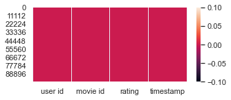

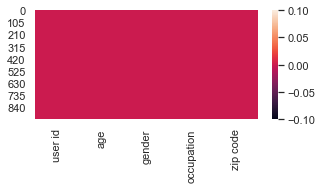

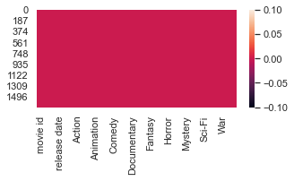

```python
plt.figure(figsize=(5, 2))
sns.heatmap(data.isna())
plt.show()

plt.figure(figsize=(5, 2))
sns.heatmap(user.isna())
plt.show()

plt.figure(figsize=(5, 2))
sns.heatmap(item.isna())
plt.show()
```

**Observations:** 1) According to the data i couldn't find any null values in any of the data which could also be seen in the heat maps. 2) Seven was the age of the lowest entery 3) Seventy-Three was the age of the oldest entery 4) The rating was based from 1 being the lowest and 5 being the max 5) There are 100000 entries for 943 different users for 1681 different movies. 6) All the genres have a datatype of int64 and the movie title and release date are both objects.

### 4. Find the number of movies per genre using the item data - 2.5 marks

```python
 item[['unknown',
        'Action',
        'Adventure',
        'Animation',
        'Childrens',
        'Comedy',
        'Crime',
        'Documentary',
        'Drama',
        'Fantasy',
        'Film-Noir',
        'Horror',
        'Musical',
        'Mystery',
        'Romance',
        'Sci-Fi',
        'Thriller',
        'War',
        'Western' ]].sum().sort_values(ascending = False)
```

```
Drama          725
Comedy         505
Thriller       251
Action         251
Romance        247
Adventure      135
Childrens      122
Crime          109
Sci-Fi         101
Horror          92
War             71
Mystery         61
Musical         56
Documentary     50
Animation       42
Western         27
Film-Noir       24
Fantasy         22
unknown          1
dtype: int64
```

**Insights:** Drama has the most movies released with 725. We cant use unknown becuase we dont know what it is. So that makes Fantasy with the lowerest released movies at 22. Last, if we use .sort_values(ascending = False), Horror and War releases are at the middle of the pack with a differance of 21 releases.

### 5. Drop the movie where the genre is unknown - 2.5 marks

```python
item.drop(['unknown'], axis=1)
# Makes a new dataframe, which doesn't have "Unknown"
```

|  | movie id | movie title | release date | Action | Adventure | Animation | Childrens | Comedy | Crime | Documentary | ... | Fantasy | Film-Noir | Horror | Musical | Mystery | Romance | Sci-Fi | Thriller | War | Western |
| --- | --- | --- | --- | --- | --- | --- | --- | --- | --- | --- | --- | --- | --- | --- | --- | --- | --- | --- | --- | --- | --- |
| 0 | 1 | Toy Story | 01-Jan-1995 | 0 | 0 | 1 | 1 | 1 | 0 | 0 | ... | 0 | 0 | 0 | 0 | 0 | 0 | 0 | 0 | 0 | 0 |
| 1 | 2 | GoldenEye | 01-Jan-1995 | 1 | 1 | 0 | 0 | 0 | 0 | 0 | ... | 0 | 0 | 0 | 0 | 0 | 0 | 0 | 1 | 0 | 0 |
| 2 | 3 | Four Rooms | 01-Jan-1995 | 0 | 0 | 0 | 0 | 0 | 0 | 0 | ... | 0 | 0 | 0 | 0 | 0 | 0 | 0 | 1 | 0 | 0 |
| 3 | 4 | Get Shorty | 01-Jan-1995 | 1 | 0 | 0 | 0 | 1 | 0 | 0 | ... | 0 | 0 | 0 | 0 | 0 | 0 | 0 | 0 | 0 | 0 |
| 4 | 5 | Copycat | 01-Jan-1995 | 0 | 0 | 0 | 0 | 0 | 1 | 0 | ... | 0 | 0 | 0 | 0 | 0 | 0 | 0 | 1 | 0 | 0 |
| ... | ... | ... | ... | ... | ... | ... | ... | ... | ... | ... | ... | ... | ... | ... | ... | ... | ... | ... | ... | ... | ... |
| 1676 | 1678 | Mat' i syn | 06-Feb-1998 | 0 | 0 | 0 | 0 | 0 | 0 | 0 | ... | 0 | 0 | 0 | 0 | 0 | 0 | 0 | 0 | 0 | 0 |
| 1677 | 1679 | B. Monkey | 06-Feb-1998 | 0 | 0 | 0 | 0 | 0 | 0 | 0 | ... | 0 | 0 | 0 | 0 | 0 | 1 | 0 | 1 | 0 | 0 |
| 1678 | 1680 | Sliding Doors | 01-Jan-1998 | 0 | 0 | 0 | 0 | 0 | 0 | 0 | ... | 0 | 0 | 0 | 0 | 0 | 1 | 0 | 0 | 0 | 0 |
| 1679 | 1681 | You So Crazy | 01-Jan-1994 | 0 | 0 | 0 | 0 | 1 | 0 | 0 | ... | 0 | 0 | 0 | 0 | 0 | 0 | 0 | 0 | 0 | 0 |
| 1680 | 1682 | Scream of Stone (Schrei aus Stein) | 08-Mar-1996 | 0 | 0 | 0 | 0 | 0 | 0 | 0 | ... | 0 | 0 | 0 | 0 | 0 | 0 | 0 | 0 | 0 | 0 |

1681 rows × 21 columns

```python
item['unknown'].value_counts()
```

```
0    1680
1       1
Name: unknown, dtype: int64
```

```python
item = item[item['unknown']!=1]
# Makes a new dataframe, which doesn't have "Unknown"
```

```python
item['unknown'].value_counts()
```

```
0    1680
Name: unknown, dtype: int64
```

### 6. Find the movies that have more than one genre - 5 marks

hint: use sum on the axis = 1

Display movie name, number of genres for the movie in dataframe

and also print(total number of movies which have more than one genres)

```python
item.columns
```

```
Index(['movie id', 'movie title', 'release date', 'unknown', 'Action',
       'Adventure', 'Animation', 'Childrens', 'Comedy', 'Crime', 'Documentary',
       'Drama', 'Fantasy', 'Film-Noir', 'Horror', 'Musical', 'Mystery',
       'Romance', 'Sci-Fi', 'Thriller', 'War', 'Western'],
      dtype='object')
```

```python
new_item = item[['movie id', 'movie title']]
```

```python
new_item["Number of Genres"] =item.loc[:,'Action':'Western'].sum(axis=1)
```

```python
new_item[new_item['Number of Genres']>1]
```

|  | movie id | movie title | Number of Genres |
| --- | --- | --- | --- |
| 0 | 1 | Toy Story | 3 |
| 1 | 2 | GoldenEye | 3 |
| 3 | 4 | Get Shorty | 3 |
| 4 | 5 | Copycat | 3 |
| 6 | 7 | Twelve Monkeys | 2 |
| ... | ... | ... | ... |
| 1667 | 1669 | MURDER and murder | 3 |
| 1668 | 1670 | Tainted | 2 |
| 1671 | 1673 | Mirage | 2 |
| 1677 | 1679 | B. Monkey | 2 |
| 1678 | 1680 | Sliding Doors | 2 |

849 rows × 3 columns

```python
new_item[new_item['Number of Genres']>1].sort_values(by='Number of Genres',ascending=False).head()
```

|  | movie id | movie title | Number of Genres |
| --- | --- | --- | --- |
| 171 | 172 | Empire Strikes Back, The | 6 |
| 558 | 560 | Kid in King Arthur's Court, A | 6 |
| 424 | 426 | Transformers: The Movie, The | 6 |
| 753 | 755 | Jumanji | 5 |
| 16 | 17 | From Dusk Till Dawn | 5 |

**Insights:** Out of 849 movies that have more then 1 genre; Empire Strikes Back,Kid in King Arthur's Court, Transformers: The Movie have the most Number of Genres at 6. Then Jumanji and From Dusk Till Dawn fall next short by 1 with 5 number of genres.